# Purrr Worksheet

Nathaniel Grimes

2023-12-15

## Purrr Definitions

1. In your own words, describe what the map functions from the `purrr` package accomplish?
2. What data type do the following functions return?
- `map()`
- `map_chr()`
- `map_dbl()`
- `map_df()`
- `map_lgl()`
3. If I have a dataset where I want to iterate over 4 variables that are changing, which of the following functions would I use?
1. `map()`
2. `map2()`
3. `pmap()`
4. `mutate()`

## Purrr Coding

1. Format the out of order code into the correct order for it to run

```r
janitor::clean_names() |>
mutate(reg=map(.x=data, ~lm(life_exp~pop+gdp_per_cap+year,data=.x))) |>
output <- gapminder |>
mutate(coeff=map(.x=reg, ~coefficients(.x)))
nest(.by=continent) |>
```

2. Purr is excellent and speeding up simulation processes without having to rely on for loops. For example we could see how different production elasticities (a,b) benefit an economy with known capital (k) and labor (l). Run through the code below. Fix the error in `try1`. Which output would you prefer between a fixed `try1` and `try2`?

```r
parameters=expand_grid(a=seq(0.1,0.8,by=.1),b=seq(0.2,1,by=.1),k=4,l=2)

cobb<-function(a,b,k,l){
  out=k^a*l^b
  return(as.data.frame(out))
}

try1<-map2_df(.x=parameters$a,.y=parameters$b,~cobb(.x,.y))

try2<-pmap_df(parameters,cobb)
```

## Purrr in action

We want to plot 6 graphs for the top 6 most expensive child care states with data from 2008 to 2018. Each graph will be child care costs on the y-axis with two lines for median weekly infant and preschool care against the x axis of years. Modify the accompanying `plot_function` to be suitable for a `purrr` map. Create your own mapping and then use cowplot, ggarrange, or gridarrange to show all the plots on one figure.

```r
# Run this code chunk to download data and get it in a good format
childcare_costs <- readr::read_csv('https://raw.githubusercontent.com/rfordatascience/tidytuesday/master/data/2023/2023-05-09/childcare_costs.csv')

counties <- readr::read_csv('https://raw.githubusercontent.com/rfordatascience/tidytuesday/master/data/2023/2023-05-09/counties.csv')

cc_clean<-childcare_costs |>
  select(county_fips_code,mc_infant,mc_preschool,study_year) |>
  full_join(counties)

top_6 <- cc_clean |>
  group_by(state_name) |>
  summarize(num=sum(is.na(mc_infant)),
            avg_cost=mean(mc_infant,na.rm=TRUE)) |>
  filter(num==0) |>
  top_n(6)

cc_plot_df <- cc_clean |>
  filter(state_name %in% top_6$state_name) |>
  group_by(state_name,study_year) |>
  summarize(avg_infant=mean(mc_infant,na.rm=T),
            avg_pre=mean(mc_preschool,na.rm=T)) |>
  pivot_longer(cols=c("avg_infant","avg_pre"),
               names_to = "childcare",
               values_to = "cost")
```

```r
#Students edit this code chunk

plot_function<-function(...){  #Fill in the ...
  p <- xxx|>  #Fill in xxx
    ggplot(yyy)+ #fill in correct ggplot (hint look at data structure)
    labs(zzz)+  #Replace the zzz with correct labs everything below is correct, don't modify.
      geom_line(linewidth=2)+
    scale_x_continuous(breaks=seq(2008,2018,by=2),labels = seq(2008,2018,by=2))+
    scale_color_manual(values=c("forestgreen","purple"),breaks=c("avg_infant","avg_pre"),labels=c("Infant","Preschool"),name="")+
    theme_bw()+
    theme(plot.title = element_text(hjust = 0.5))
  return(p)
}
```

```r
# Correct plot_function
plot_function<-function(df,name){
  p <- df |>
    ggplot(aes(x=study_year,y=cost,color=childcare))+
      geom_line(linewidth=2)+
    scale_x_continuous(breaks=seq(2008,2018,by=2),labels = seq(2008,2018,by=2))+
    scale_color_manual(values=c("forestgreen","purple"),breaks=c("avg_infant","avg_pre"),labels=c("Infant","Preschool"),name="")+
      labs(x="",y="Average weekly\nchildcare cost",title =name)+
    theme_bw()+
    theme(plot.title = element_text(hjust = 0.5))
  return(p)
}
```

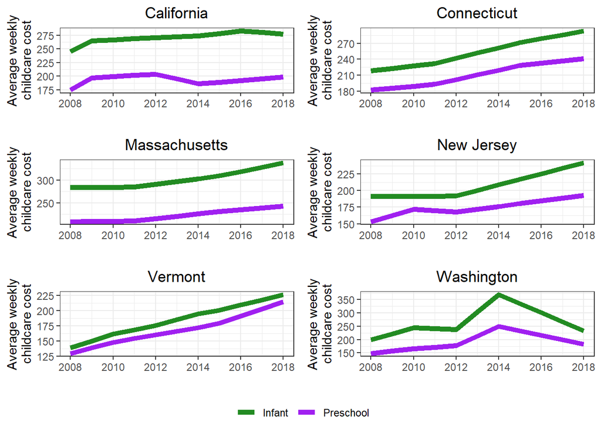

```r
# How students should graph and use purrr
plot_list<-cc_plot_df |>
  group_by(state_name) |>
  nest() |>
  mutate(plots=map2(.x=data,.y=state_name,~plot_function(.x,.y)))


ggpubr::ggarrange(plotlist=plot_list$plots, ncol=2, nrow=3, common.legend = TRUE, legend="bottom")
```

### Complete the following tasks with purrr

1. Generate 10 random samples from a normal distribution where the mean and standard deviation increase from 1 to 10 and to 20. Hint: Make sure the sequences are of the same length by setting the length.out=11 argument in seq()
2. Use purrr to quickly return the class of every column from the `gapminder` dataset as characters

```r
# 1. Generate random draws

mean_in<-seq(1,10,length.out=11)
sd_in<-seq(2,20,length.out=11)

map2(mean_in,sd_in,~rnorm(n=10,mean=.x,sd=.y))
```

```
## [[1]]
##  [1]  0.3330219  4.1880866 -0.9801619  1.7113692  1.7048870 -1.0939265
##  [7]  0.9357221  0.7228613  1.4461100  1.5145092
##
## [[2]]
##  [1] 3.15491857 2.31389086 9.42713884 4.34801134 5.40564698 2.79069855
##  [7] 4.86704989 6.72043425 0.02102254 4.59514665
##
## [[3]]
##  [1] -5.3205112 -4.4282813  4.6719215 -2.4993439  5.2527438 10.5464674
##  [7]  2.0121783  2.8082533  5.8688868  0.5115666
##
## [[4]]
##  [1] 15.1331092 -2.8984633  3.3209665  5.9007460 -0.4230934  7.1270794
##  [7] -0.6339452 17.3392248  4.9641622  9.9279183
##
## [[5]]
##  [1] -7.7877175  1.2507920 11.5629408  0.2137921 12.9183385  7.3018783
##  [7]  0.1625730  9.3542770 -2.4648853 17.3105236
##
## [[6]]
##  [1]  19.256955   5.990646 -12.469927  11.590859   8.410673 -11.112869
##  [7]   4.795486   9.660492  -2.218835  15.249237
##
## [[7]]
##  [1]  5.606081 16.438646  6.242053 14.213260 20.875846 -9.155605 12.732319
##  [8]  3.293636  6.310384 -8.181057
##
## [[8]]
##  [1]  10.9729472  -7.6950022  -3.8024532  32.6715869  -0.9073592  -2.0549171
##  [7]  -5.9248460 -27.4153522   4.5435349   7.6274269
##
## [[9]]
##  [1]   7.0525501   1.6903220   4.5150984   3.1875550  -3.1461081   2.7454067
##  [7]  -6.2614790 -17.7600926   0.6847509  17.0516490
##
## [[10]]
##  [1]   0.01075127  -5.10038023  -4.34995150  -4.82765414  35.44963858
##  [6]  18.50726693   8.54580979 -18.63419615  20.28551875 -17.11454902
##
## [[11]]
##  [1]  45.355875  22.331852 -15.586841  15.787082   6.722438  -3.900901
##  [7]  22.033459  24.301240  13.267175  23.318789
```

```r
# 2.

gapminder |> map_chr(class)
```

```
##   country continent      year   lifeExp       pop gdpPercap
##  "factor"  "factor" "integer" "numeric" "integer" "numeric"
```